# What is wrong with the data

Juan Rocha

12/6/2016

## Intro

This short report is meant to exemplify the problems I encountered dealing with TAI data. We have worked with many different versions of the dataset, each one with different executive decisions that we have not been documenting properly. Here I take the most recent version of the raw data (Katja’s version after fieldwork, files from 161117 without replacing missing values), and try to walk you through the analysis of the paper documenting the choices I made.

## The data

The data was cleaned and formated in long format on a separate script avaialble on my Github repository TAI-Volta, file name `161201_ExtractData.R`. It extracts the data from each excel file per country, combine it on a unique dataset object on long format.

```r
## Useful functions for later
volta.only <- function(x){
  x <- x [ is.element (x$TAI_ID1, volta.shp@data$TAI_ID1 ), ]
  x <- droplevels(x)
}

### Normalizing by scaling everything to 0:1
rescale_hw <- function (x){ # This is Hadley Wickman function from his book R for DataScience
  rng <- range(x, na.rm= TRUE, finite = TRUE)
  (x - rng[1]) / (rng[2] - rng[1])
}

### Correct the numeric format from excel files
correct.num <- function (x){
  l <- length(x)
  x[3:l] <- apply (x[3:l], 2, function (x){as.numeric(x)} )
  return(x)
}

## Update this with new importing data code
setwd("~/Documents/Projects/TAI/TransformedData/Data_Burkina&Ganha")
# load map for visualizations and data
volta.shp <- readShapeSpatial("~/Documents/Projects/TAI/TransformedData/Bundling/Volta_bundling1.shp")


## Read data
load('~/Documents/Projects/TAI/TransformedData/Data_Burkina&Ganha/161205_Volta.RData')

#### kcals and dams data
    dams <- read_excel(path = 'Volta_Dam_density_KLC.xlsx', sheet = 1)
    kcals <- read_excel("crop_kcals.xlsx", sheet = 1)


## Select only volta places
data <- dat %>% volta.only()

### SES variables for later
#### New file with raw values from Katja: 160901
file <- 'Volta_Vars_raw_160901.xlsx'
sn <- sheetNames(xls=file)


dams$TAI_ID2 <- as.factor(dams$TAI_ID1)
# dat <- left_join(dat, dams, by = c("ADM_2", "TAI_ID2"))

users <- read.xls(file, sheet=2, dec=',')
users <- correct.num(users)
users$TAI_ID1 <- as.factor(users$TAI_ID1)
resource <- read.xls (file, sheet=3, dec=',')
biophys <- resource [c(1,2,11:15)]
resource <- resource [-c(11:15)]
biophys <- correct.num(biophys)
resource <- correct.num(resource)
resource$TAI_ID1 <- as.factor(resource$TAI_ID1)
resource <- left_join(resource, dplyr::select(dams, TAI_ID2, Dams), by = c("TAI_ID1" = "TAI_ID2"))

biophys$TAI_ID1 <- as.factor(biophys$TAI_ID1)
biophys$Aridity <- 1-biophys$Aridity  # Invert the scale so results are easy to interpret.
resource <- resource[-c(9)] #delete dams density
# biophys <- read.xls(file, sheet=3, dec=',')

# Threre is 3 datasets for interactions depending on the sheet in Katjas file
# 4 = kcals per distric area in sq.km
# 5 = kcals_harv.area
# 6 = ratio_harv.area
# 7 = other
# interact <- read.xls(file,sheet=5, dec=',')
# interact <- correct.num(interact)
# interact <- volta.only(interact)


head(data)
```

```
##    TAI_ID1 Year  crop   area  prod
## 3     3103 2000 Maize  3.452  7718
## 8     3108 2000 Maize  3.971  7846
## 13    3113 2000 Maize 15.500  5095
## 16    3116 2000 Maize  6.038 11232
## 17    3117 2000 Maize  9.161 15070
## 18    3118 2000 Maize 14.178 27982
```

```r
str(data)
```

```
## 'data.frame':    31200 obs. of  5 variables:
##  $ TAI_ID1: Factor w/ 99 levels "1113","1115",..: 40 41 42 43 44 45 46 47 48 49 ...
##  $ Year   : num  2000 2000 2000 2000 2000 2000 2000 2000 2000 2000 ...
##  $ crop   : Factor w/ 33 levels "Cabbage","Carrot",..: 13 13 13 13 13 13 13 13 13 13 ...
##  $ area   : num  3.45 3.97 15.5 6.04 9.16 ...
##  $ prod   : num  7718 7846 5095 11232 15070 ...
```

## Dealing with missing values

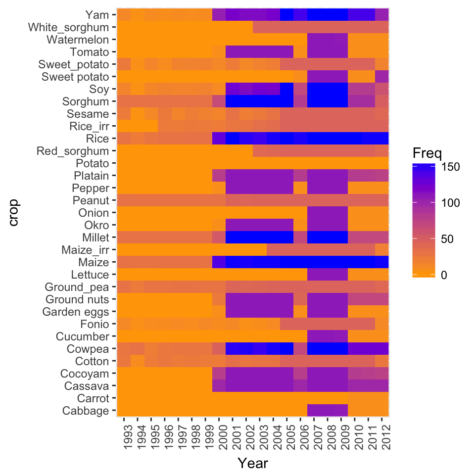

```r
missing <- as.data.frame(with(filter(dat, !is.na(area), !is.na(prod)), table(Year, crop)))
g <- ggplot(missing, aes(Year, crop)) + geom_raster(aes(fill = Freq))
g + scale_fill_gradient(low = "#FFA50080", high = "#0000FF80") + theme(axis.text.x = element_text(angle = 90, hjust = 1))
```

```r
## only key crops
datKeyCrops <- (filter(data, crop == 'Maize' | crop == 'Millet'| crop == 'Rice'| crop == 'Yam'| crop == 'Sorghum'| crop == 'Cowpea'| crop == 'Soy' ))

datKeyCrops <- drop.levels(datKeyCrops)

## only years with most complete information (3% NA)
datKeyCrops <- (filter(datKeyCrops, Year > 2001, Year < 2010, Year !=2006))

datKeyCrops$TAI_ID2 <- datKeyCrops$TAI_ID1

## Crop dat is now dat from the ExtracDataTAI file
crop.dat <- datKeyCrops
crop.dat$country <- ifelse(as.numeric(as.character(crop.dat$TAI_ID1)) > 3000, 'GH', 'BF')


crop.dat <- crop.dat %>%
        mutate(sq_prod = sqrt(prod), sq_area = sqrt(area)) %>%
        mutate( #dt_prod = sq_prod - mean(sq_prod), Los detrending tienen que calcularse en el agregado de cada TAI_ID1, no para todos los datos!!!
            # dt_area = sq_area - mean(sq_area),
            log_prod = log(1+prod),
            yield = ifelse(prod == 0 | area == 0, 0, prod/area),
            log_yield = log(1+yield),
            log_area = log(1+area)
        )

tot.area <- crop.dat %>%
  dplyr::select (TAI_ID2, crop, area, Year) %>%
  group_by ( TAI_ID2, Year) %>%
  summarize (tot_area = sum(area, na.rm = TRUE))

crop.dat <- left_join(crop.dat, tot.area, by = c("TAI_ID2", 'Year'))
crop.dat <- crop.dat %>%
  mutate(prop_cultivated_area = area / tot_area )


### Calculate the 7 year mean
crop.area <- crop.dat %>%
    dplyr::select(TAI_ID2, crop, log_area, Year) %>%
    group_by(TAI_ID2, crop) %>%
    summarize(mean_area = mean(log_area, na.rm= TRUE))

## remember we are using log-transformed area

## Now do the same for kcals

# kcals
crops.nam <- tolower(levels(crop.dat$crop))
# crops.nam[2] <- 'taro' # cocoyam is aka. taro
crops.nam[6] <- 'soybean'
crops.nam %in% kcals$CROPNAME
```

```
## [1] TRUE TRUE TRUE TRUE TRUE TRUE TRUE
```

```r
cals.fao <- filter(kcals, CROPNAME %in% crops.nam) %>% dplyr::select(crop = CROPNAME, kcals_fao = kcals.per.ton.fao)

cals.fao$crop <- as.factor(cals.fao$crop)
levels(cals.fao$crop) <- levels(crop.dat$crop)

crop.dat <- left_join(crop.dat, cals.fao, by = c("crop"))
crop.dat <- crop.dat %>%
        mutate(kcal_crop = (log_prod * kcals_fao))
# remember we are using log-transformed production.

kcals2 <- crop.dat %>%
    dplyr::select(TAI_ID2, crop, kcal_crop, Year) %>%
    group_by(TAI_ID2, crop) %>%
    summarize(mean_kcal = mean(kcal_crop, na.rm= TRUE))

dat.int <- left_join(crop.area, kcals2, by = c('TAI_ID2', 'crop'))

# #interaction dataset: select the mean for kcals (log)
interact <- dplyr::select(dat.int, TAI_ID2, crop, mean_kcal) %>%
tidyr::spread( key = crop, value = mean_kcal) %>% dplyr::rename(m_cowpea = Cowpea, m_maize = Maize, m_millet = Millet, m_rice = Rice, m_sorghum = Sorghum, m_soy = Soy, m_yam = Yam)

## add the selection of mean area (log)
interact <- left_join(interact, (dplyr::select(dat.int, TAI_ID2, crop, mean_area) %>%
tidyr::spread( key = crop, value = mean_area) %>% dplyr::rename(a_cowpea = Cowpea, a_maize = Maize, a_millet = Millet, a_rice = Rice, a_sorghum = Sorghum, a_soy = Soy, a_yam = Yam)))
str(datKeyCrops)
```

```
## 'data.frame':    4851 obs. of  6 variables:
##  $ TAI_ID1: Factor w/ 99 levels "1113","1115",..: 40 41 42 43 44 45 46 47 48 49 ...
##  $ Year   : num  2002 2002 2002 2002 2002 ...
##  $ crop   : Factor w/ 7 levels "Cowpea","Maize",..: 2 2 2 2 2 2 2 2 2 2 ...
##  $ area   : num  3594 4134 32978 6286 9537 ...
##  $ prod   : num  7790 9954 41499 11337 34157 ...
##  $ TAI_ID2: Factor w/ 99 levels "1113","1115",..: 40 41 42 43 44 45 46 47 48 49 ...
```

```r
str(interact)
```

```
## Classes 'grouped_df', 'tbl_df', 'tbl' and 'data.frame':  99 obs. of  15 variables:
##  $ TAI_ID2  : Factor w/ 99 levels "1113","1115",..: 1 2 3 4 5 6 7 8 9 10 ...
##  $ m_cowpea : num  28858728 29104521 33226280 26681555 29376524 ...
##  $ m_maize  : num  29175427 36841949 30060957 36918789 36308587 ...
##  $ m_millet : num  38490311 34951840 34177489 31869694 34985518 ...
##  $ m_rice   : num  15826237 19441740 24203465 18693397 20069433 ...
##  $ m_sorghum: num  36673353 37573737 35296252 36063107 36667437 ...
##  $ m_soy    : num  6747725 15924121 0 6795807 14343088 ...
##  $ m_yam    : num  0e+00 0e+00 0e+00 0e+00 3e+06 ...
##  $ a_cowpea : num  7.37 8.35 6.23 7.18 8.17 ...
##  $ a_maize  : num  8.34 9.94 7.83 9.96 9.98 ...
##  $ a_millet : num  11.36 10.28 10.31 9.37 10.28 ...
##  $ a_rice   : num  5.68 6.36 7.7 5.9 6.34 ...
##  $ a_sorghum: num  10.7 10.9 10.5 10.4 10.7 ...
##  $ a_soy    : num  2.42 5.1 0 2.07 5.05 ...
##  $ a_yam    : num  0 0 0 0 2.37 ...
##  - attr(*, "vars")=List of 1
##   ..$ : symbol TAI_ID2
```

On the code chunk above I selected only the crops for which we have close to complete data. All data was log-transformed, total crop area calculated as well as the proportion of cultivated area per crop. Production in Tons was transformed to Kcals with data from FAO provided by Kate. And the mean for a 7 year period (skipping 2006) will be used for the interaction dataset in the clustering. Note that I’m keeping areas and kcals separately. I did calculate yields, but I’m not using it by recommendation of Kate and Katja. Here ‘area’ is used as a proxy of how much labour people put into crops, while kcals is how much reward, or how important it is for food security. I believe keeping both is important because: i) both have been present in our discussions and previous analysis, ii) as highlighted by Katja, they capture difference nuances of the data; and iii) if we use yield it tell us about the productivity of the land, not the labour that people put in nor the benefits people get from the cropping activities (the SES interaction in Ostrom’s framework). The data for key crops has 4851 observations of which 4664 does NOT contain missing values. Now instead of >30% of missing data, we only have 3.85%. But who is missing? The following table tells you which provices by `TAI_ID1` are missing data points, it should be 7 (for 7 years) on the count under Freq.

```r
x <- with(filter(datKeyCrops, !is.na(area), !is.na(prod)) , table(TAI_ID1, crop)) %>% as.data.frame() %>% filter (Freq != 7)
x
```

```
##    TAI_ID1   crop Freq
## 1     1436 Cowpea    6
## 2     1828 Cowpea    6
## 3     2020 Cowpea    6
## 4     2321 Cowpea    6
## 5     1501   Rice    5
## 6     1523   Rice    6
## 7     2020   Rice    5
## 8     2039   Rice    6
## 9     2045   Rice    5
## 10    2137   Rice    6
## 11    1113    Soy    4
## 12    1127    Soy    4
## 13    1131    Soy    4
## 14    1132    Soy    6
```

[output cut: 61 more lines]

As you see from the long table above, we have 75 places where one or more data points in time are missing. When the data is close to zero is fair to assume it is zero when missing, but when is not close to zero, what we do by automatically replacing NA by zeroes is inflating the zeroes in our distributions and biasing the 7 yr means with zeroes that does not exist. To give you an example by examining the third case from the long table above:

```r
i = 3
datKeyCrops %>% filter(crop == x[i,2], TAI_ID2 == x[i,1])
```

```
##   TAI_ID1 Year   crop   area    prod TAI_ID2
## 1    2020 2002 Cowpea 1060.2 18914.5    2020
## 2    2020 2003 Cowpea     NA 26783.8    2020
## 3    2020 2004 Cowpea  752.1 17749.5    2020
## 4    2020 2005 Cowpea 1182.3 30496.1    2020
## 5    2020 2007 Cowpea  305.2 22486.9    2020
## 6    2020 2008 Cowpea  312.7 17781.9    2020
## 7    2020 2009 Cowpea 1080.4 25315.7    2020
```

Dropping a zero on the data above for the district with `TAI_ID 2020` would be gross mistake: i) it will biase the mean, and ii) if one were to calculate or use the yield, it will through an error of division by zero. On the example below it is reasonable to assume the missing values to be zero, in fact zero is the mean of the existing observations.

```r
i = 49
datKeyCrops %>% filter(crop == x[i,2], TAI_ID2 == x[i,1])
```

```
##   TAI_ID1 Year crop area prod TAI_ID2
## 1    1311 2002  Yam   NA   NA    1311
## 2    1311 2003  Yam   NA   NA    1311
## 3    1311 2004  Yam   NA   NA    1311
## 4    1311 2005  Yam    0    0    1311
## 5    1311 2007  Yam    0    0    1311
## 6    1311 2008  Yam    0    0    1311
## 7    1311 2009  Yam    0    0    1311
```

The problem is, the assumption of zero is context dependent, it works for certain crops in certain areas, but if we applied without thinking where the zeroes are landing, we are fouling ourselves. Zero inflated data leads to highly skewed distributions that the clustering algorithm cannot tell appart. The more crops we incorporate where we add zeroes is recreating the problem. Currently we transform the raw data to logarithms to avoid highly skewed distributions, adding zeroes to a significantly large amount of missing data (say 10 or 20% of our datapoints) will bias the results and make it hard to trust them, or defend them from the reviewers.

## Current analysis

The current analysis is a conservative effort to make it work by dropping most of the incomplete information. The idea is to run an analysis that is fool proof, where if something does not work we understand where the errors come from.

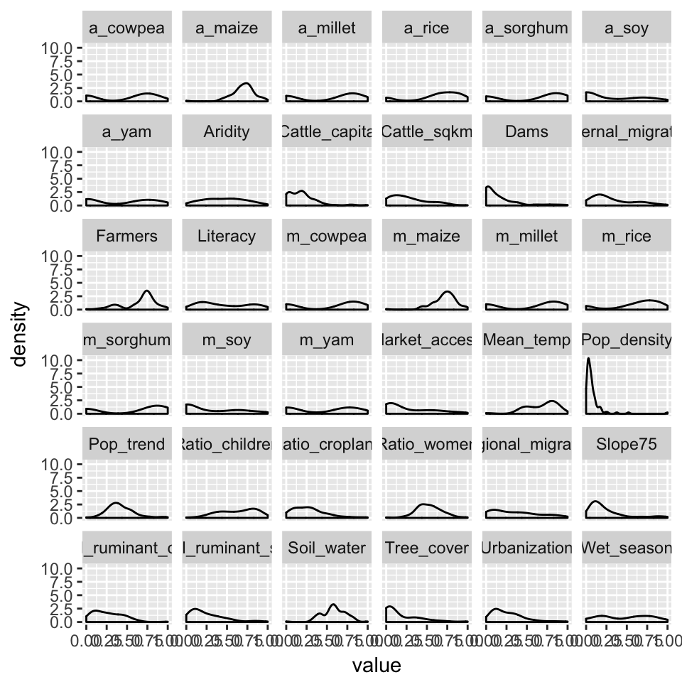

```r
### Combine all datasets for clustering all
dat <- left_join(users, resource, by = c("TAI_ID1", "ADM_2"))
dat <- left_join(dat, biophys, by = c("TAI_ID1", "ADM_2"))
dat$TAI_ID2 <- as.factor(dat$TAI_ID1)
interact$TAI_ID2 <- as.factor(interact$TAI_ID2)
dat <- left_join(dat, interact, by = c("TAI_ID2"))

# delete columns that wont be used.
dat <- dat[,-c(1,2,4)] # no pop_log_density, ADM_2 or TAI_ID1.

# Note this is non-normalized data, original values. After the following line all is "rescaled" to 0-1
dat[-23] <- apply(dat[-23], 2, rescale_hw)

## Using mahalanobis distance help us dealing with colinearity or strong correlations.
d <- vegdist(dat[-c(23)], method = "mahalanobis", tol= 10e-20)

# X dataset for plotting final distributions in ggplot
x <- gather(dat[-23], key = variable)
x$variable <- as.factor(x$variable)

g <- ggplot (x, aes(value), group = x) + geom_density()
g+ facet_wrap(~variable)
```

```r
## Validating number of clusters
## Number of clusters with NdClust: uses 30 different index and compare them to decide the optimal partition
library (NbClust)
# euclidean and manhattan are not good for gradient separation (see help vegdist)
m <- 'ward.D2'
clust_num <- NbClust( data = dat[-c(23)], dist = 'manhattan',
                      min.nc = 3, max.nc = 12, method = m, alphaBeale = 0.1, index = 'all')
```

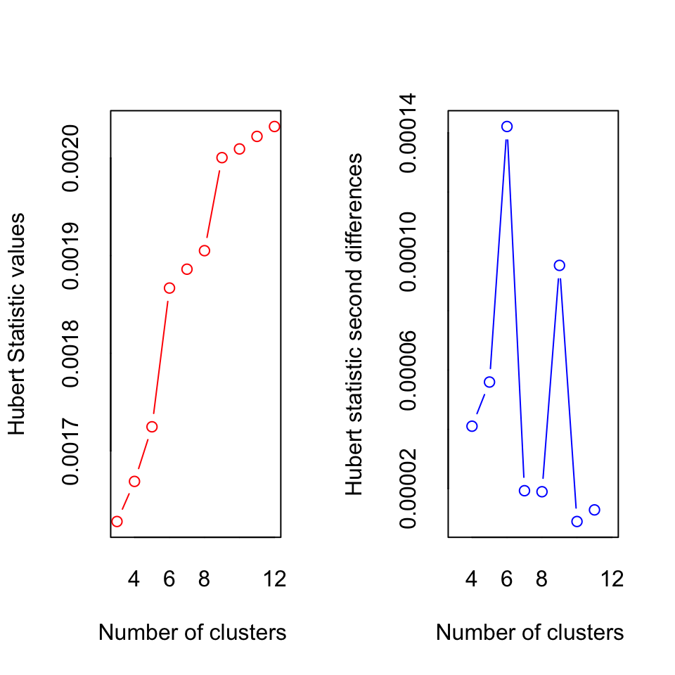

```
## *** : The Hubert index is a graphical method of determining the number of clusters.
##                 In the plot of Hubert index, we seek a significant knee that corresponds to a
##                 significant increase of the value of the measure i.e the significant peak in Hubert
##                 index second differences plot.
##
```

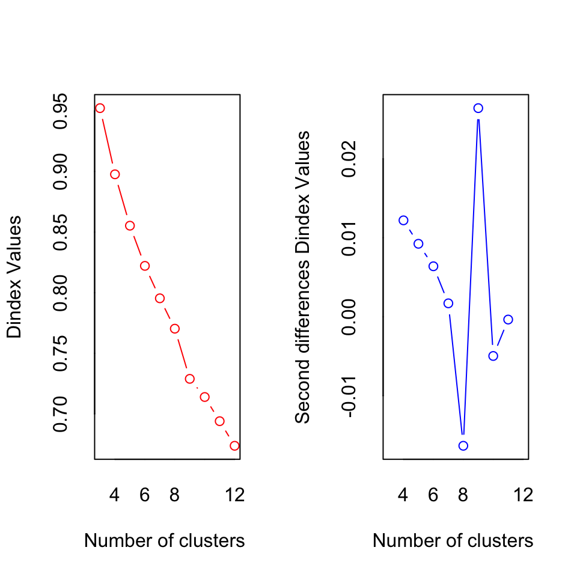

```
## *** : The D index is a graphical method of determining the number of clusters.
##                 In the plot of D index, we seek a significant knee (the significant peak in Dindex
##                 second differences plot) that corresponds to a significant increase of the value of
##                 the measure.
##
## * Among all indices:
## * 10 proposed 3 as the best number of clusters
## * 3 proposed 4 as the best number of clusters
## * 1 proposed 5 as the best number of clusters
## * 3 proposed 9 as the best number of clusters
## * 3 proposed 10 as the best number of clusters
## * 4 proposed 12 as the best number of clusters
##
##                    ***** Conclusion *****
##
## * According to the majority rule, the best number of clusters is  3
##
##
```

```r
clust_num_mb <- NbClust( data = dat[-c(23)], diss = d, dist = NULL,
                    min.nc = 3, max.nc = 12, method = m, alphaBeale = 0.1, index = 'all')
```

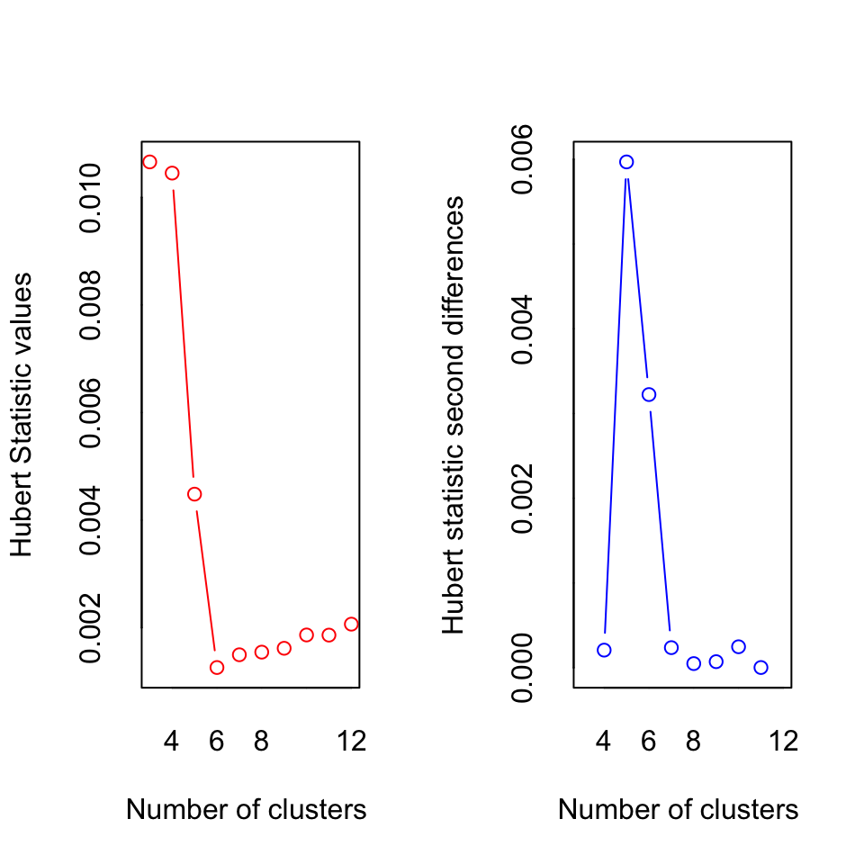

```
## *** : The Hubert index is a graphical method of determining the number of clusters.
##                 In the plot of Hubert index, we seek a significant knee that corresponds to a
##                 significant increase of the value of the measure i.e the significant peak in Hubert
##                 index second differences plot.
##
```

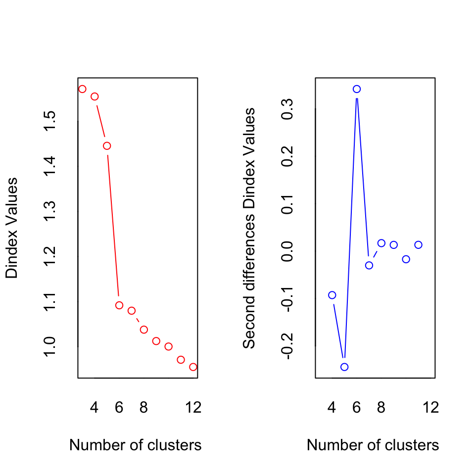

```
## *** : The D index is a graphical method of determining the number of clusters.
##                 In the plot of D index, we seek a significant knee (the significant peak in Dindex
##                 second differences plot) that corresponds to a significant increase of the value of
##                 the measure.
##
## * Among all indices:
## * 7 proposed 3 as the best number of clusters
## * 6 proposed 4 as the best number of clusters
## * 8 proposed 6 as the best number of clusters
## * 2 proposed 7 as the best number of clusters
##
##                    ***** Conclusion *****
##
## * According to the majority rule, the best number of clusters is  6
##
##
```

The only combination that suggest 6 clusters is including: ratio of cropland, cattle and rummians per capita, and soil water; all of them were suggested to drop by Katja in our last skype meeting. My worry is that the analysis is incredibly sensible to what we put inside, most of the time it suggest 3 clusters (because that’s the minimum option, if I allow 2 that is the preferred option). Now, what the `NbClust` routine does is taking the dataset, clustering with Wald method and compare 30 different indexes that were designed to help elucidate what is the best number of clusters. The result is the number of indexes that support different numbers of clusters. I’ve been using Ward agglomeration method because the authors of the paper suggest that this method minimizes the tota within-cluster variance. In previous attempts it worked better with higher numbers of clusters, and it was also used and suggested by JB and the coral reefs group. When I tried different alternatives, ‘single’ agglomeartion methods on the manhattan distance reder 4 clusters, as well as ‘kmeans’ on the mahalanobis distance.

```r
library(clValid)
# Internal validation
intern <- clValid(obj=as.data.frame(dat[-c(23)]), nClust=c(3:9),
                  clMethods=c('hierarchical', 'kmeans', 'diana', 'fanny','som',
                              'pam', 'sota', 'clara', 'model'),
                  validation='internal')
```

```
## Package 'mclust' version 5.2
```

```r
## Stability validation
stab <- clValid(obj=as.data.frame(dat[-c(23)]), nClust=c(3:9),
                clMethods=c('hierarchical', 'kmeans', 'diana', 'fanny', 'som',
                            'pam', 'sota', 'clara', 'model'),
                validation='stability')
summary(intern)
```

```
##
## Clustering Methods:
##  hierarchical kmeans diana fanny som pam sota clara model
##
## Cluster sizes:
##  3 4 5 6 7 8 9
##
## Validation Measures:
##                                  3       4       5       6       7       8       9
##
## hierarchical Connectivity   3.0956  6.0246  8.9536 13.3361 20.7575 24.8599 27.7889
##              Dunn           0.5127  0.4893  0.5049  0.5064  0.3028  0.3028  0.3259
##              Silhouette     0.3728  0.3083  0.2357  0.2356  0.2707  0.2549  0.2419
## kmeans       Connectivity   7.9381 18.0893 26.7210 30.3329 27.3687 36.4079 41.3591
##              Dunn           0.2429  0.2245  0.2514  0.2514  0.2719  0.3062  0.3062
##              Silhouette     0.3548  0.3147  0.2185  0.2397  0.2614  0.2598  0.2619
## diana        Connectivity  14.1770 17.1060 24.8774 27.8063 30.3853 33.9972 36.1067
##              Dunn           0.2192  0.2204  0.2408  0.2589  0.2622  0.2833  0.2941
##              Silhouette     0.3574  0.2589  0.2514  0.2437  0.2352  0.2568  0.2500
## fanny        Connectivity   7.9381      NA      NA      NA      NA      NA      NA
##              Dunn           0.2429      NA      NA      NA      NA      NA      NA
##              Silhouette     0.3548      NA      NA      NA      NA      NA      NA
## som          Connectivity   7.9381 26.9452 26.7210 35.6857 34.4353 60.0984 57.3611
##              Dunn           0.2429  0.2666  0.2514  0.2683  0.2514  0.2297  0.2830
##              Silhouette     0.3548  0.2393  0.2185  0.1992  0.2359  0.2102  0.2047
## pam          Connectivity  20.3107 27.1694 31.5520 41.6369 54.8167 58.5413 60.0706
##              Dunn           0.2244  0.2396  0.2396  0.1897  0.2366  0.2125  0.2719
##              Silhouette     0.3406  0.2906  0.2293  0.2289  0.2018  0.1976  0.1975
## sota         Connectivity   7.9381 25.6385 28.0524 38.2885 49.3238 52.1929 61.6448
##              Dunn           0.2429  0.2666  0.2666  0.2719  0.2683  0.2683  0.2806
##              Silhouette     0.3548  0.2574  0.2722  0.2287  0.2155  0.2147  0.2054
## clara        Connectivity  17.3786 27.1694 31.5520 41.6369 64.9206 64.3706 66.8611
##              Dunn           0.2132  0.2396  0.2396  0.1897  0.1775  0.2388  0.2388
##              Silhouette     0.3447  0.2906  0.2293  0.2289  0.1949  0.1954  0.1942
## model        Connectivity  11.1131 21.5421 31.2639 34.8758 50.4992 57.9254 64.9155
##              Dunn           0.2429  0.2429  0.2666  0.2666  0.2551  0.2798  0.2798
##              Silhouette     0.3515  0.3110  0.2090  0.2322  0.1896  0.1883  0.1911
##
## Optimal Scores:
##
##              Score  Method       Clusters
## Connectivity 3.0956 hierarchical 3
## Dunn         0.5127 hierarchical 3
## Silhouette   0.3728 hierarchical 3
```

```r
# Optimal Scores:
#
#   Score   Method       Clusters
# Connectivity 10.2159 hierarchical 3
# Dunn          0.3697 hierarchical 5
# Silhouette    0.3444 hierarchical 3


summary(stab)
```

```
##
## Clustering Methods:
##  hierarchical kmeans diana fanny som pam sota clara model
##
## Cluster sizes:
##  3 4 5 6 7 8 9
##
## Validation Measures:
##                        3      4      5      6      7      8      9
##
## hierarchical APN  0.0006 0.0011 0.0060 0.0170 0.0155 0.0161 0.0205
##              AD   1.4727 1.4454 1.4193 1.3570 1.2066 1.1618 1.1437
##              ADM  0.0017 0.0041 0.0119 0.0302 0.0863 0.0615 0.0710
##              FOM  0.1744 0.1721 0.1714 0.1670 0.1612 0.1570 0.1562
## kmeans       APN  0.0138 0.0238 0.0327 0.0249 0.0834 0.0608 0.1044
##              AD   1.3271 1.2482 1.1847 1.1192 1.1519 1.1067 1.0856
##              ADM  0.0251 0.0410 0.0738 0.0477 0.1006 0.0853 0.1400
##              FOM  0.1649 0.1548 0.1533 0.1489 0.1466 0.1443 0.1424
## diana        APN  0.0194 0.0937 0.0187 0.0227 0.0450 0.0378 0.0679
##              AD   1.4419 1.4153 1.2330 1.2040 1.1866 1.1224 1.1043
##              ADM  0.0577 0.1501 0.0440 0.0349 0.0751 0.0506 0.0797
##              FOM  0.1758 0.1729 0.1548 0.1528 0.1516 0.1452 0.1438
## fanny        APN  0.0057     NA     NA     NA     NA     NA     NA
##              AD   1.3229     NA     NA     NA     NA     NA     NA
##              ADM  0.0094     NA     NA     NA     NA     NA     NA
##              FOM  0.1614     NA     NA     NA     NA     NA     NA
## som          APN  0.0303 0.1055 0.0867 0.1519 0.1739 0.2342 0.1740
##              AD   1.3694 1.3003 1.2141 1.1893 1.1638 1.1412 1.0849
##              ADM  0.1415 0.1849 0.1728 0.2388 0.2691 0.3343 0.2572
##              FOM  0.1682 0.1616 0.1531 0.1513 0.1483 0.1439 0.1447
## pam          APN  0.0248 0.0730 0.0872 0.0594 0.0819 0.0384 0.0528
##              AD   1.3383 1.2895 1.2277 1.1676 1.1189 1.0531 1.0143
##              ADM  0.0390 0.1041 0.1160 0.0829 0.1138 0.0533 0.0724
##              FOM  0.1640 0.1607 0.1560 0.1529 0.1485 0.1411 0.1388
## sota         APN  0.0638 0.0167 0.0175 0.0334 0.0450 0.0675 0.0469
##              AD   1.3860 1.2578 1.2031 1.1364 1.0969 1.0729 1.0285
##              ADM  0.2101 0.0279 0.0312 0.0696 0.0785 0.0910 0.0728
##              FOM  0.1724 0.1600 0.1558 0.1536 0.1482 0.1475 0.1433
## clara        APN  0.0240 0.0407 0.0396 0.0820 0.0616 0.0911 0.0783
##              AD   1.3350 1.2793 1.2152 1.1749 1.1101 1.0819 1.0462
##              ADM  0.0409 0.0528 0.0527 0.1106 0.0800 0.1290 0.1181
##              FOM  0.1635 0.1568 0.1518 0.1506 0.1416 0.1426 0.1391
## model        APN  0.0687 0.0736 0.1038 0.1049 0.1218 0.1376 0.1126
##              AD   1.3606 1.2777 1.2338 1.1595 1.1250 1.0906 1.0348
##              ADM  0.1369 0.1149 0.2106 0.1655 0.1780 0.2020 0.1558
##              FOM  0.1657 0.1588 0.1570 0.1510 0.1485 0.1441 0.1366
##
## Optimal Scores:
##
##     Score  Method       Clusters
## APN 0.0006 hierarchical 3
## AD  1.0143 pam          9
## ADM 0.0017 hierarchical 3
## FOM 0.1366 model        9
```

```r
# Optimal Scores:
#
#   Score  Method       Clusters
# APN 0.0006 hierarchical 5
# AD  0.9623 kmeans       9
# ADM 0.0026 hierarchical 5
# FOM 0.1385 som          9
```

## Recommendations

**Dealing with correlations:** There is to some degree correlations in our data. When consulting with the statistician at Princeton he recommended using the Mahalanobis distance in our clustering exercise, its formula includes a covariance matrix that takes into account correlations. Since then I have kept both distances “manhattan” and “mahalanobis” in our clustering identification routine. Manhattan was at fist better when finding higher numbers of clusters, but the current best result (6 clusters) was using mahalanobis. The statistician was emphatic that correlations should not be a problem doing clustering because it is correlated datapoints that allows any algorithm to classify them as closer together, hence belonging to the same group. A data without correlation should find little to no clusters.

**Adding crops back** In our latest conversation with Katja she suggest that cocoyam, cassava, ground nuts and to some extent plantain should be back into the dataset of key crops. For these crops one can safely assume that `NA` are real zeroes.

```r
datKeyCrops <- (filter(data, crop == 'Maize' | crop == 'Millet'| crop == 'Rice'| crop == 'Yam'| crop == 'Sorghum'| crop == 'Cowpea'| crop == 'Soy'| crop == 'Cassava'| crop == 'Cocoyam'| crop == 'Ground nuts' | crop == "Platain"   ))

datKeyCrops <- drop.levels(datKeyCrops)

## only years with most complete information (3% NA)
datKeyCrops <- (filter(datKeyCrops, Year > 2001, Year < 2010, Year !=2006))

datKeyCrops$TAI_ID2 <- datKeyCrops$TAI_ID1

## Crop dat is now dat from the ExtracDataTAI file
crop.dat <- datKeyCrops
crop.dat$country <- ifelse(as.numeric(as.character(crop.dat$TAI_ID1)) > 3000, 'GH', 'BF')

## lets assume zero for all
crop.dat$area[is.na(crop.dat$area)] <- 0
crop.dat$prod[is.na(crop.dat$prod)] <- 0

crop.dat <- crop.dat %>%
        mutate(sq_prod = sqrt(prod), sq_area = sqrt(area)) %>%
        mutate( #dt_prod = sq_prod - mean(sq_prod), Los detrending tienen que calcularse en el agregado de cada TAI_ID1, no para todos los datos!!!
            # dt_area = sq_area - mean(sq_area),
            log_prod = log(1+prod),
            yield = ifelse(prod == 0 | area == 0, 0, prod/area),
            log_yield = log(1+yield),
            log_area = log(1+area)
        )

tot.area <- crop.dat %>%
  dplyr::select (TAI_ID2, crop, area, Year) %>%
  group_by ( TAI_ID2, Year) %>%
  summarize (tot_area = sum(area, na.rm = TRUE))

crop.dat <- left_join(crop.dat, tot.area, by = c("TAI_ID2", 'Year'))
crop.dat <- crop.dat %>%
  mutate(prop_cultivated_area = area / tot_area )


### Calculate the 7 year mean
crop.area <- crop.dat %>%
    dplyr::select(TAI_ID2, crop, log_area, Year) %>%
    group_by(TAI_ID2, crop) %>%
    summarize(mean_area = mean(log_area, na.rm= TRUE))

## remember we are using log-transformed area

## Now do the same for kcals

# kcals
crops.nam <- tolower(levels(crop.dat$crop))
crops.nam[2] <- 'taro' # cocoyam is aka. taro
crops.nam[10] <- 'soybean'
crops.nam[4] <- 'groundnut'
crops.nam[7] <- 'plantain'
# crops.nam %in% kcals$CROPNAME

cals.fao <- filter(kcals, CROPNAME %in% crops.nam) %>% dplyr::select(crop = CROPNAME, kcals_fao = kcals.per.ton.fao)

cals.fao$crop <- as.factor(cals.fao$crop)
levels(cals.fao$crop) <- levels(crop.dat$crop)

crop.dat <- left_join(crop.dat, cals.fao, by = c("crop"))
crop.dat <- crop.dat %>%
        mutate(kcal_crop = (log_prod * kcals_fao))
# remember we are using log-transformed production.

kcals2 <- crop.dat %>%
    dplyr::select(TAI_ID2, crop, kcal_crop, Year) %>%
    group_by(TAI_ID2, crop) %>%
    summarize(mean_kcal = mean(kcal_crop, na.rm= TRUE))

dat.int <- left_join(crop.area, kcals2, by = c('TAI_ID2', 'crop'))

# #interaction dataset: select the mean for kcals (log)
interact <- dplyr::select(dat.int, TAI_ID2, crop, mean_kcal) %>%
tidyr::spread( key = crop, value = mean_kcal) %>% dplyr::rename(m_cowpea = Cowpea, m_maize = Maize, m_millet = Millet, m_rice = Rice, m_sorghum = Sorghum, m_soy = Soy, m_yam = Yam, m_cassava = Cassava, m_cocoyam = Cocoyam, m_plantain = Platain)
colnames(interact)[5]<-"m_groundnuts"

int2 <- dplyr::select(dat.int, TAI_ID2, crop, mean_area) %>%
tidyr::spread( key = crop, value = mean_area) %>% dplyr::rename(a_cowpea = Cowpea, a_maize = Maize, a_millet = Millet, a_rice = Rice, a_sorghum = Sorghum, a_soy = Soy, a_yam = Yam, a_cassava = Cassava, a_cocoyam = Cocoyam, a_plantain = Platain)
colnames(int2)[5]<-"a_groundnuts"

## add the selection of mean area (log)
interact <- left_join(interact, int2 )
rm(int2)

## Note that interact has created 39 NA in the added crops because we don't have data for all years. I proceed to fill with zeroes

interact$m_cassava[is.na(interact$m_cassava)] <- 0
interact$m_cocoyam[is.na(interact$m_cocoyam)] <- 0
interact$m_groundnuts[is.na(interact$m_groundnuts)] <- 0
interact$m_plantain[is.na(interact$m_plantain)] <- 0
interact$a_plantain[is.na(interact$a_plantain)] <- 0
interact$a_cassava[is.na(interact$a_cassava)] <- 0
interact$a_cocoyam[is.na(interact$a_cocoyam)] <- 0
interact$a_groundnuts[is.na(interact$a_groundnuts)] <- 0

summary(interact)
```

```
##     TAI_ID2     m_cassava          m_cocoyam           m_cowpea
##  1113   : 1   Min.   :       0   Min.   :       0   Min.   :       0
##  1115   : 1   1st Qu.:       0   1st Qu.:       0   1st Qu.:       0
##  1127   : 1   Median :       0   Median :       0   Median :31627409
##  1131   : 1   Mean   : 5960377   Mean   : 9031000   Mean   :22422149
##  1132   : 1   3rd Qu.:12297566   3rd Qu.:23535440   3rd Qu.:36878851
##  1140   : 1   Max.   :14214311   Max.   :36649841   Max.   :43076417
##  (Other):93
##   m_groundnuts         m_maize            m_millet
##  Min.   :       0   Min.   : 6701015   Min.   :      0
##  1st Qu.:       0   1st Qu.:28020364   1st Qu.:      0
##  Median :       0   Median :30772896   Median :6372297
##  Mean   : 8218970   Mean   :30034891   Mean   :4442410
##  3rd Qu.:13246062   3rd Qu.:32962725   3rd Qu.:7230126
##  Max.   :38308243   Max.   :39263506   Max.   :8490510
##
##    m_plantain           m_rice           m_sorghum
##  Min.   :       0   Min.   :       0   Min.   :       0
##  1st Qu.:       0   1st Qu.:16531874   1st Qu.:       0
##  Median :       0   Median :23383084   Median :30121844
##  Mean   : 7831502   Mean   :20308652   Mean   :21311729
##  3rd Qu.:21607128   3rd Qu.:27759569   3rd Qu.:33965715
##  Max.   :31910125   Max.   :33224217   Max.   :37552388
##
##      m_soy             m_yam            a_cassava        a_cocoyam
##  Min.   :      0   Min.   :       0   Min.   : 0.000   Min.   :0.000
##  1st Qu.:      0   1st Qu.:       0   1st Qu.: 0.000   1st Qu.:0.000
##  Median : 505553   Median : 8475328   Median : 0.000   Median :0.000
##  Mean   :1792409   Mean   : 5850567   Mean   : 4.282   Mean   :2.101
##  3rd Qu.:3598262   3rd Qu.:10469020   3rd Qu.: 8.726   3rd Qu.:5.475
##  Max.   :6717832   Max.   :13189198   Max.   :10.512   Max.   :8.693
##
##     a_cowpea      a_groundnuts       a_maize          a_millet
##  Min.   :0.000   Min.   : 0.000   Min.   : 2.906   Min.   : 0.000
##  1st Qu.:0.000   1st Qu.: 0.000   1st Qu.: 8.033   1st Qu.: 0.000
##  Median :6.377   Median : 0.000   Median : 8.698   Median : 8.591
##  Mean   :4.669   Mean   : 2.285   Mean   : 8.599   Mean   : 6.005
##  3rd Qu.:7.722   3rd Qu.: 2.858   3rd Qu.: 9.261   3rd Qu.: 9.760
##  Max.   :9.873   Max.   :10.534   Max.   :11.033   Max.   :11.714
##
##    a_plantain        a_rice        a_sorghum          a_soy
##  Min.   :0.000   Min.   :0.000   Min.   : 0.000   Min.   :0.0000
##  1st Qu.:0.000   1st Qu.:4.552   1st Qu.: 0.000   1st Qu.:0.0000
##  Median :0.000   Median :6.134   Median : 8.957   Median :0.4214
##  Mean   :2.174   Mean   :5.443   Mean   : 6.375   Mean   :2.0879
##  3rd Qu.:5.857   3rd Qu.:7.470   3rd Qu.:10.110   3rd Qu.:4.3908
##  Max.   :9.237   Max.   :8.817   Max.   :11.370   Max.   :7.5238
##
##      a_yam
##  Min.   : 0.000
##  1st Qu.: 0.000
##  Median : 5.955
##  Mean   : 4.370
##  3rd Qu.: 7.964
##  Max.   :10.185
##
```

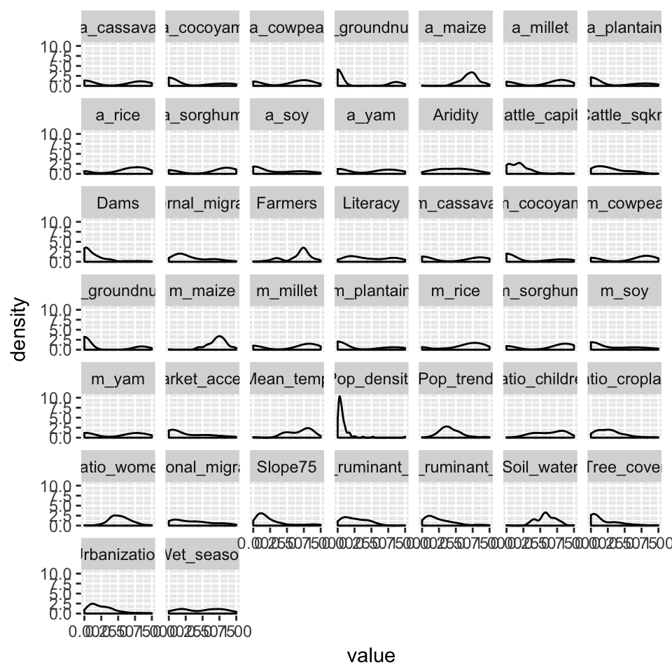

```r
##
### Combine all datasets for clustering all
dat <- left_join(users, resource, by = c("TAI_ID1", "ADM_2"))
dat <- left_join(dat, biophys, by = c("TAI_ID1", "ADM_2"))
dat$TAI_ID2 <- as.factor(dat$TAI_ID1)
interact$TAI_ID2 <- as.factor(interact$TAI_ID2)
dat <- left_join(dat, interact, by = c("TAI_ID2"))

# delete columns that wont be used.
dat <- dat[,-c(1,2,4)] # no pop_log_density, ADM_2 or TAI_ID1.

# Note this is non-normalized data, original values. After the following line all is "rescaled" to 0-1
dat[-23] <- apply(dat[-23], 2, rescale_hw)

## Using mahalanobis distance help us dealing with colinearity or strong correlations.
d <- vegdist(dat[-c(23)], method = "mahalanobis", tol= 10e-20)

# X dataset for plotting final distributions in ggplot
x <- gather(dat[-23], key = variable)
x$variable <- as.factor(x$variable)

g <- ggplot (x, aes(value), group = x) + geom_density()
g+ facet_wrap(~variable)
```

```r
## Validating number of clusters
## Number of clusters with NdClust: uses 30 different index and compare them to decide the optimal partition
library (NbClust)
# euclidean and manhattan are not good for gradient separation (see help vegdist)
m <- 'ward.D2'
clust_num <- NbClust( data = dat[-c(23)], dist = 'manhattan',
                      min.nc = 3, max.nc = 12, method = m, alphaBeale = 0.1, index = 'all')
```

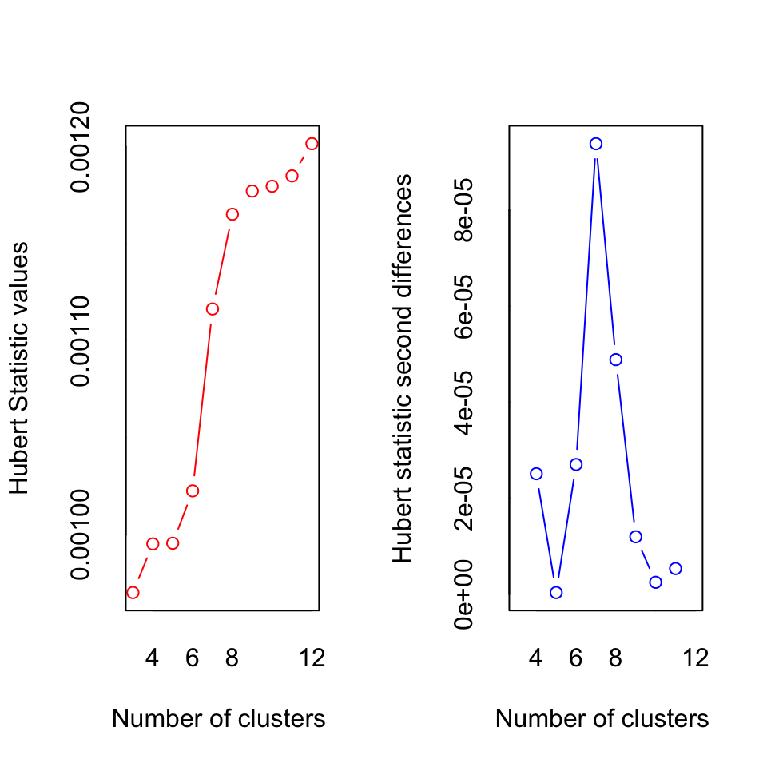

```
## *** : The Hubert index is a graphical method of determining the number of clusters.
##                 In the plot of Hubert index, we seek a significant knee that corresponds to a
##                 significant increase of the value of the measure i.e the significant peak in Hubert
##                 index second differences plot.
##
```

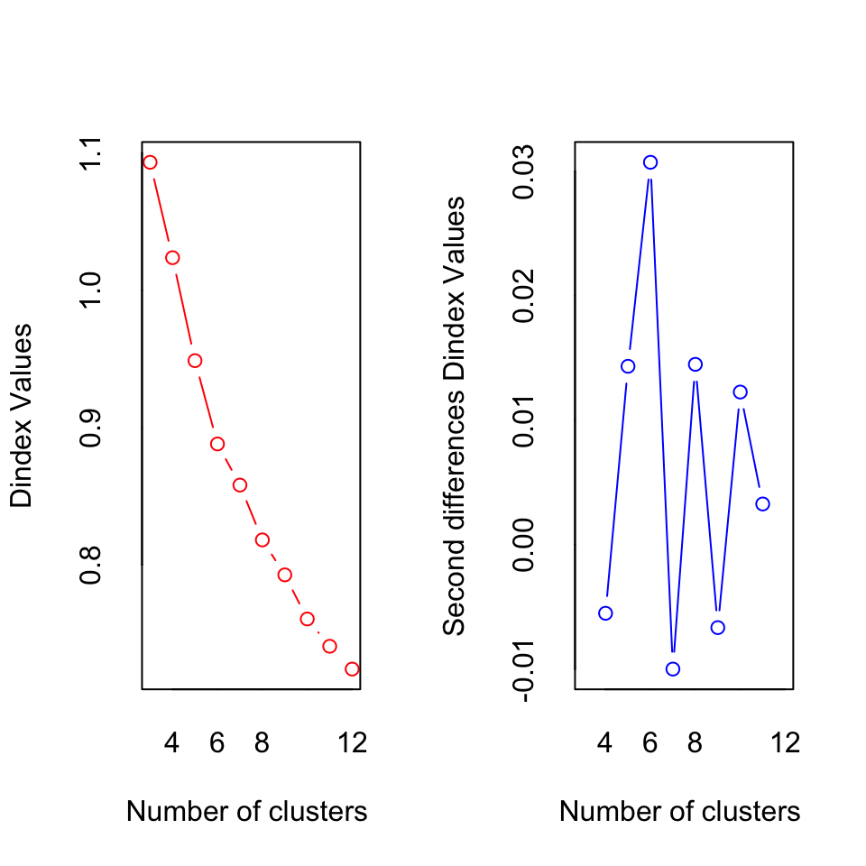

```
## *** : The D index is a graphical method of determining the number of clusters.
##                 In the plot of D index, we seek a significant knee (the significant peak in Dindex
##                 second differences plot) that corresponds to a significant increase of the value of
##                 the measure.
##
## * Among all indices:
## * 6 proposed 3 as the best number of clusters
## * 5 proposed 4 as the best number of clusters
## * 2 proposed 5 as the best number of clusters
## * 1 proposed 6 as the best number of clusters
## * 1 proposed 9 as the best number of clusters
## * 5 proposed 10 as the best number of clusters
## * 1 proposed 11 as the best number of clusters
## * 2 proposed 12 as the best number of clusters
##
##                    ***** Conclusion *****
##
## * According to the majority rule, the best number of clusters is  3
##
##
```

```r
clust_num_mb <- NbClust( data = dat[-c(23)], diss = d, dist = NULL,
                    min.nc = 3, max.nc = 12, method = m, alphaBeale = 0.1, index = 'all')
```

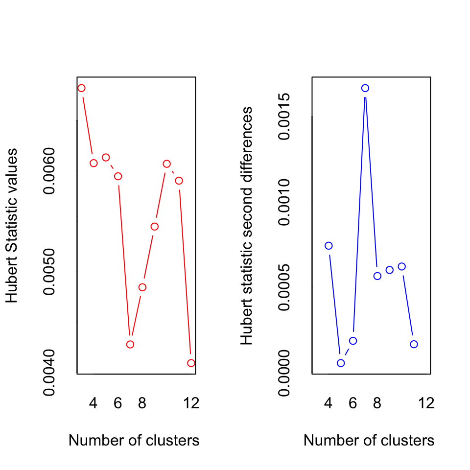

```
## *** : The Hubert index is a graphical method of determining the number of clusters.
##                 In the plot of Hubert index, we seek a significant knee that corresponds to a
##                 significant increase of the value of the measure i.e the significant peak in Hubert
##                 index second differences plot.
##
```

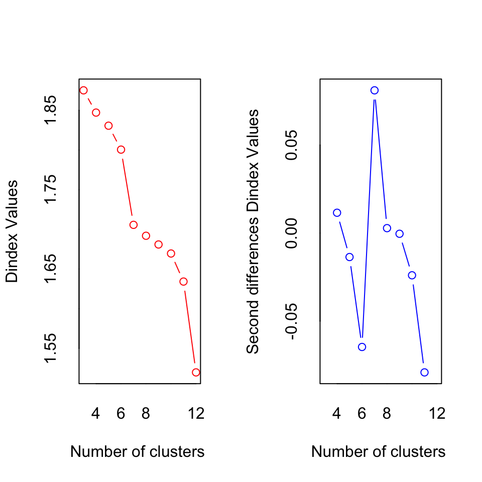

```
## *** : The D index is a graphical method of determining the number of clusters.
##                 In the plot of D index, we seek a significant knee (the significant peak in Dindex
##                 second differences plot) that corresponds to a significant increase of the value of
##                 the measure.
##
## * Among all indices:
## * 11 proposed 3 as the best number of clusters
## * 4 proposed 4 as the best number of clusters
## * 3 proposed 7 as the best number of clusters
## * 2 proposed 8 as the best number of clusters
## * 1 proposed 11 as the best number of clusters
## * 3 proposed 12 as the best number of clusters
##
##                    ***** Conclusion *****
##
## * According to the majority rule, the best number of clusters is  3
##
##
```

```r
library(clValid)
# Internal validation
intern <- clValid(obj=as.data.frame(dat[-c(23)]), nClust=c(3:9),
                  clMethods=c('hierarchical', 'kmeans', 'diana', 'fanny','som',
                              'pam', 'sota', 'clara', 'model'),
                  validation='internal')
## Stability validation
stab <- clValid(obj=as.data.frame(dat[-c(23)]), nClust=c(3:9),
                clMethods=c('hierarchical', 'kmeans', 'diana', 'fanny', 'som',
                            'pam', 'sota', 'clara', 'model'),
                validation='stability')
summary(intern)
```

```
##
## Clustering Methods:
##  hierarchical kmeans diana fanny som pam sota clara model
##
## Cluster sizes:
##  3 4 5 6 7 8 9
##
## Validation Measures:
##                                  3       4       5       6       7       8       9
##
## hierarchical Connectivity   4.7075  8.0294 10.9583 17.8464 19.6194 22.5484 25.4774
##              Dunn           0.5683  0.4133  0.4133  0.4923  0.5119  0.5625  0.5625
##              Silhouette     0.3986  0.3845  0.3464  0.3184  0.3321  0.3074  0.2960
## kmeans       Connectivity   6.7702 10.0921 13.1544 23.9024 32.4528 39.1615 42.0905
##              Dunn           0.4015  0.4573  0.3203  0.3610  0.3158  0.3394  0.3394
##              Silhouette     0.3961  0.3785  0.3547  0.3194  0.2949  0.2786  0.2699
## diana        Connectivity   3.3218 10.0921 20.0726 29.8238 32.6528 34.0317 34.5968
##              Dunn           0.4133  0.4573  0.3242  0.2904  0.2923  0.3283  0.3386
##              Silhouette     0.4144  0.3785  0.3214  0.2398  0.2344  0.2357  0.2677
## fanny        Connectivity   8.1448      NA      NA      NA      NA      NA      NA
##              Dunn           0.2274      NA      NA      NA      NA      NA      NA
##              Silhouette     0.4025      NA      NA      NA      NA      NA      NA
## som          Connectivity   1.7730  8.5433 14.9444 15.0091 31.8190 48.1722 51.0738
##              Dunn           0.4270  0.4573  0.3178  0.3671  0.3008  0.2537  0.2787
##              Silhouette     0.4116  0.3704  0.3576  0.3221  0.2752  0.2329  0.2196
## pam          Connectivity  14.7313 22.4782 33.9440 25.2925 38.3742 38.5317 48.2516
##              Dunn           0.2190  0.2461  0.2461  0.2594  0.2647  0.2647  0.3029
##              Silhouette     0.4036  0.3663  0.2909  0.3224  0.2653  0.2660  0.2514
## sota         Connectivity   1.7730 16.2341 18.8655 24.1067 25.2484 41.3722 46.5048
##              Dunn           0.4270  0.2063  0.2063  0.2230  0.2230  0.2245  0.2245
##              Silhouette     0.4116  0.3400  0.3301  0.3180  0.3024  0.2883  0.2753
## clara        Connectivity  14.7313 26.1972 29.8536 25.2925 37.0794 53.8639 54.0214
##              Dunn           0.2190  0.2190  0.2461  0.2594  0.2641  0.2647  0.2647
##              Silhouette     0.4036  0.3272  0.2920  0.3224  0.3161  0.2470  0.2494
## model        Connectivity   5.9659 15.7881 20.4956 32.4944 43.7885 47.1103 56.5242
##              Dunn           0.4175  0.2391  0.2391  0.2391  0.2637  0.2637  0.2637
##              Silhouette     0.3885  0.3179  0.2916  0.2783  0.2054  0.2325  0.2419
##
## Optimal Scores:
##
##              Score  Method       Clusters
## Connectivity 1.7730 som          3
## Dunn         0.5683 hierarchical 3
## Silhouette   0.4144 diana        3
```

```r
summary(stab)
```

```
##
## Clustering Methods:
##  hierarchical kmeans diana fanny som pam sota clara model
##
## Cluster sizes:
##  3 4 5 6 7 8 9
##
## Validation Measures:
##                        3      4      5      6      7      8      9
##
## hierarchical APN  0.0266 0.0204 0.0235 0.0266 0.0238 0.0115 0.0164
##              AD   1.6812 1.4244 1.3972 1.3555 1.2976 1.2157 1.1973
##              ADM  0.0678 0.0510 0.0576 0.0829 0.1643 0.0410 0.0571
##              FOM  0.1857 0.1639 0.1629 0.1629 0.1598 0.1504 0.1508
## kmeans       APN  0.0171 0.0109 0.0548 0.1025 0.1112 0.0216 0.0337
##              AD   1.6680 1.4105 1.3309 1.2945 1.2258 1.1152 1.0986
##              ADM  0.0458 0.0264 0.1045 0.1723 0.2504 0.0479 0.0721
##              FOM  0.1845 0.1589 0.1494 0.1480 0.1426 0.1417 0.1418
## diana        APN  0.0253 0.0109 0.0159 0.0799 0.0857 0.0953 0.0698
##              AD   1.5763 1.4105 1.3491 1.3152 1.3019 1.2631 1.1485
##              ADM  0.1681 0.0264 0.0361 0.2209 0.2446 0.2409 0.1611
##              FOM  0.1843 0.1589 0.1570 0.1516 0.1511 0.1412 0.1383
## fanny        APN  0.0190     NA     NA     NA     NA     NA     NA
##              AD   1.5238     NA     NA     NA     NA     NA     NA
##              ADM  0.0415     NA     NA     NA     NA     NA     NA
##              FOM  0.1750     NA     NA     NA     NA     NA     NA
## som          APN  0.0690 0.0296 0.1470 0.0506 0.2109 0.0994 0.1048
##              AD   1.6174 1.4210 1.3768 1.2666 1.2762 1.1771 1.1313
##              ADM  0.3358 0.0858 0.2665 0.1661 0.3617 0.1754 0.1690
##              FOM  0.1728 0.1588 0.1521 0.1457 0.1489 0.1363 0.1384
## pam          APN  0.0140 0.0532 0.0349 0.0095 0.0209 0.0649 0.0353
##              AD   1.5258 1.4425 1.3501 1.2261 1.1683 1.1378 1.0862
##              ADM  0.0325 0.1040 0.0815 0.0234 0.0436 0.1001 0.0591
##              FOM  0.1724 0.1694 0.1597 0.1433 0.1407 0.1363 0.1370
## sota         APN  0.0062 0.0036 0.0077 0.0081 0.0221 0.0600 0.0828
##              AD   1.5190 1.4239 1.3601 1.2644 1.2386 1.2167 1.1728
##              ADM  0.0335 0.0313 0.0179 0.0218 0.0392 0.1358 0.1251
##              FOM  0.1773 0.1671 0.1583 0.1503 0.1497 0.1482 0.1458
## clara        APN  0.0144 0.0617 0.0393 0.0135 0.1175 0.0549 0.0745
##              AD   1.5260 1.4564 1.3463 1.2289 1.2242 1.1463 1.1123
##              ADM  0.0334 0.1096 0.0799 0.0305 0.1808 0.0847 0.1247
##              FOM  0.1723 0.1653 0.1594 0.1477 0.1494 0.1396 0.1296
## model        APN  0.0339 0.0184 0.0286 0.0511 0.0845 0.0790 0.0835
##              AD   1.5706 1.4399 1.3466 1.2807 1.2357 1.1742 1.1425
##              ADM  0.0767 0.0391 0.0652 0.0959 0.1697 0.1599 0.2117
##              FOM  0.1778 0.1667 0.1587 0.1511 0.1498 0.1453 0.1427
##
## Optimal Scores:
##
##     Score  Method Clusters
## APN 0.0036 sota   4
## AD  1.0862 pam    9
## ADM 0.0179 sota   5
## FOM 0.1296 clara  9
```

## conclusion

Deleting variables or adding crops replacing NA’s by zeroes does not improve the fitting. Most combinations of data columns tested render low numbers of clusters. Few combinations have gave us 7 clusters (September aka paper version), 6 clusters (report last week TAI), and 4 clusters (kmeans).